# ES 207 HW2

Erik Bolch

1. Using the help documentation, provide an alternative useage for the function ncol()

An alternative use of ncol() could be to determine if an object has dimensions associated with it. For example when ncol function is used on a vector as opposed to an array or matrix it will return NULL.

```r
#?ncol
m<-matrix(1:10, 2,5)
m
```

```
##      [,1] [,2] [,3] [,4] [,5]
## [1,]    1    3    5    7    9
## [2,]    2    4    6    8   10
```

```r
ncol(m)
```

```
## [1] 5
```

```r
NCOL(m)
```

```
## [1] 5
```

```r
v<-1:10
v
```

```
##  [1]  1  2  3  4  5  6  7  8  9 10
```

```r
ncol(v)
```

[output not shown]

```r
NCOL(v)
```

```
## [1] 1
```

2. Make sure to clone the tutorial repo to a new repo in your GitHub account called es207_hw2. I will check your repo, so don’t skip this step!

https://github.com/ebolch/es207_hw2

3. Convert RMarkdown_Demo_1.R into a well commented and easy to follow R Markdown document. Turn this in as a .pdf document separate from the rest of your homework assignment. Call it “yourlastname_demo_1.pdf”.

https://github.com/ebolch/es207_hw2/blob/master/bolch_demo_1.pdf

4. Complete the remaining homework below as a well-commented and easy to follow R Markdown notebook with approriate accompanying text. Turn this in as a .html document. Call it “yourlastname_hw2.html”.

5. Create and print a new vector, w that is a subset of the first 4 elements of vector v, where v <- c(8:19)

```r
v <- c(8:19)
v
```

```
##  [1]  8  9 10 11 12 13 14 15 16 17 18 19
```

```r
w <- v[1:4]
w
```

```
## [1]  8  9 10 11
```

6. Create and print a new vector, h that is a subset of the middle 5 elements of vector d, where d <- c(8:20)

```r
d <- c(8:20)
d
```

```
##  [1]  8  9 10 11 12 13 14 15 16 17 18 19 20
```

```r
h <- d[5:9]
h
```

```
## [1] 12 13 14 15 16
```

7. What is the length of vector w from above?

```r
length(w)
```

```
## [1] 4
```

8. What are the 3 properties of a vector, other than its contents?

The 3 preperties of a vector other than contents are type, length, and attributes.

9. Can you predict the output of the following uses of c()? c(3,FALSE) c(“a”,1) c(4L,2)

c(3,FALSE) will be a double because logical variables can be coerced to numbers, c(“a”,1) will be a character because “a” is a character and the most flexible type, and c(4L,2) will be a double because it contains a number and another value that’s not an integer.

```r
typeof(c(3,FALSE))
```

```
## [1] "double"
```

```r
typeof(c("a",1))
```

```
## [1] "character"
```

```r
typeof(c(4L,2))
```

```
## [1] "double"
```

10. What are the 4 types of common atomic vectors? What are the 2 rare types?

The 4 types of common atomic vectors are, double, integer, character, and logical. The two rare types are complex and raw.

11. Why is 1==“1” true? Why is -1 < FALSE true? Why is "one< 2 false?’

Coercion will happen automatically when using operators in r, the data type will be coerced based on the operator. In the first example, double 1 will be coerced to character “1”. In the second example, the logical FALSE will be coerced into a 0, which is less than 1, and in the final example, R will fail to coerce the vectors into logical, which results in False.

12. Why is the default missing value NA, a logical vector? What’s so special about logical vectors? Hint: think about c(FALSE,NA_character)

Because it only has 2 options, either it is NA or it has a value.

13. Provide the value of the last element in the result of the vector operation d * 2 from the vectors defined above.

```r
d.2<-d*2
d.2
```

```
##  [1] 16 18 20 22 24 26 28 30 32 34 36 38 40
```

```r
d.2[length(d.2)]
```

```
## [1] 40
```

14. Create a vector a with a sequence of 11 elements in it ranging from 0.6 to 1.9. Create another, logical vector b that identifies which elements in a are greater than or equal to 1.1. Print your results.

```r
a<-seq(0.6,1.9, length = 11)
a
```

```
##  [1] 0.60 0.73 0.86 0.99 1.12 1.25 1.38 1.51 1.64 1.77 1.90
```

```r
b<-a[a>=1.1]
b
```

```
## [1] 1.12 1.25 1.38 1.51 1.64 1.77 1.90
```

15. Set all elements in vector a from above to 2.0 if they are greater than or equal to 1.1.

```r
a[a>=1.1]<-2
a
```

```
##  [1] 0.60 0.73 0.86 0.99 2.00 2.00 2.00 2.00 2.00 2.00 2.00
```

16. Use str() to compare the results of using list() and c() on l and j for: l <-c(list(1,2),c(3,4)) and j=list(list(1,2),c(3,4))

```r
l <- c(list(1,2),c(3,4))
j <- list(list(1,2),c(3,4))

str(l)
```

```
## List of 4
##  $ : num 1
##  $ : num 2
##  $ : num 3
##  $ : num 4
```

```r
str(j)
```

```
## List of 2
##  $ :List of 2
##   ..$ : num 1
##   ..$ : num 2
##  $ : num [1:2] 3 4
```

List(list()) nests a list within the first.

17. Show what happens when you use unlist() on l and j.

```r
unlist(l)
```

```
## [1] 1 2 3 4
```

```r
unlist(j)
```

```
## [1] 1 2 3 4
```

18. If factors are essentially integers under the hood, why do we use them, and not just use integers (e.g., 1s and 2s instead of “male”, “female”)?

For large numbers of levels, remembering or having to associate a number with a level would be hard to remember/more complicated.

19. Using table(), provide the frequency of no and yes in my.fac.

```r
my.fac <- factor(c("yes", "yes", "no", "yes", "yes", "yes"))
my.fac
```

```
## [1] yes yes no  yes yes yes
## Levels: no yes
```

```r
table(my.fac)
```

```
## my.fac
##  no yes
##   1   5
```

20. What does this R code below do? How are f1 and f2 different from f3?

f1 - This code generates a vector of all letters of class factor, then settings the levels of f1 to rev(levels(f1)), reverses the order of the letters in the levels of the factor.

f2 - this code reverses the vector of levels that is of class factor, after the levels have been generated by factor(), so they remain in alphabetical order.

f3 - This code creates a vector of letters of class factor, and reverses the order of the levels of the factors.

These differ because of the order in which functions are applied, and because factors have multiple components, a vector and its associated levels.

```r
f1 <- factor(letters)
levels(f1) <-rev(levels(f1))
f2 <- rev(factor(letters))
f3 <- factor(letters, levels=rev(letters))
f1
```

```
##  [1] z y x w v u t s r q p o n m l k j i h g f e d c b a
## Levels: z y x w v u t s r q p o n m l k j i h g f e d c b a
```

```r
f2
```

```
##  [1] z y x w v u t s r q p o n m l k j i h g f e d c b a
## Levels: a b c d e f g h i j k l m n o p q r s t u v w x y z
```

```r
f3
```

```
##  [1] a b c d e f g h i j k l m n o p q r s t u v w x y z
## Levels: z y x w v u t s r q p o n m l k j i h g f e d c b a
```

21. If is.matrix(x) is TRUE, what will is.array(x) return?

False because an array will have an extra dimension (layers).

22. Why didn’t that work? Hint: read the errors

This doesnt work because there are 3 ages, not 2 in the ages vector. Since there are a different number of rows in the vectors, they can’t be put into a data frame like this.

```r
f <- data.frame(kids=c("Jack","Jill"),ages=c(12,11))
f
```

```
##   kids ages
## 1 Jack   12
## 2 Jill   11
```

```r
#f <- data.frame(kids=c("Jack","Jill"),ages=c(12,10,11))
#f
```

BONUS. What is a tibble? Why might it be better than a data frame? Why might it be worse?

It may be better or worse depending on what you want. A tibble will read in the kids names as character vectors, while a dataframe will read them in as factors. If you want factors, such as when you’ll be separating something based on a feature, this may not be helpful. If you’re not doing this, and you have to manipulate the information in the kids column, you’ll have to delete/modify the levels after you make changes.

```r
#f2 <- tibble(kids=c("Jack","Jill"),ages=c(12,10))
#f2
```

23. What does as.matrix() do when applied to a data frame with columns of different types?

The vectors are coerced into type “character”.

```r
f.mat<-as.matrix(f)
f.mat
```

```
##      kids   ages
## [1,] "Jack" "12"
## [2,] "Jill" "11"
```

24. What if we don’t have the same variable name? Change the data frame variables names using names(d2) <- c(“ages”,“kids”). Then, use the help documentation to merge d1 and d2. Print your results.

```r
d1 <- data.frame(names = c("Jack", "Jill", "John"), states = c("CA", "IL", "IL"))
d2 <- data.frame(ages = c(10, 7, 12), names = c("Jill", "Jillian", "Jack"))
d1
```

```
##   names states
## 1  Jack     CA
## 2  Jill     IL
## 3  John     IL
```

```r
d2
```

```
##   ages   names
## 1   10    Jill
## 2    7 Jillian
## 3   12    Jack
```

```r
merge(d1,d2)
```

```
##   names states ages
## 1  Jack     CA   12
## 2  Jill     IL   10
```

```r
names(d2) <- c("ages","kids")
merge(d1,d2)
```

```
##   names states ages    kids
## 1  Jack     CA   10    Jill
## 2  Jill     IL   10    Jill
## 3  John     IL   10    Jill
## 4  Jack     CA    7 Jillian
## 5  Jill     IL    7 Jillian
## 6  John     IL    7 Jillian
## 7  Jack     CA   12    Jack
## 8  Jill     IL   12    Jack
## 9  John     IL   12    Jack
```

```r
merge(d1,d2, by.x = "names", by.y = "kids")
```

```
##   names states ages
## 1  Jack     CA   12
## 2  Jill     IL   10
```

25. Can you have a data frame with 0 rows? What about 0 columns?

Yes, if it has no information in it (NULL).

```r
a <- data.frame(NULL)
class(a)
```

```
## [1] "data.frame"
```

```r
ncol(a)
```

```
## [1] 0
```

```r
nrow(a)
```

```
## [1] 0
```

26. Plot a histogram of all the Sepal.Width values in the dataset iris that are less than or equal to 3.0.

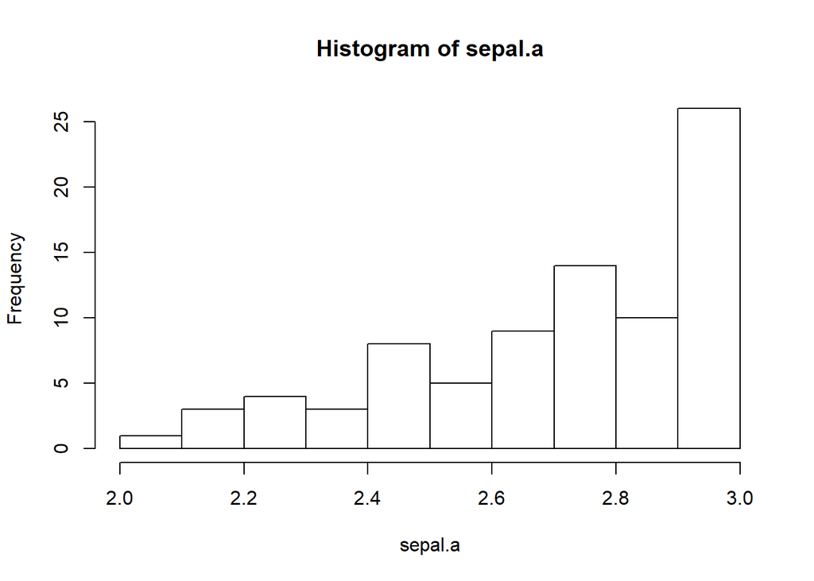

```r
sepal.a <- iris$Sepal.Width[iris$Sepal.Width<=3]
iris.hist<-hist(sepal.a)
```

```r
iris.hist
```

```
## $breaks
##  [1] 2.0 2.1 2.2 2.3 2.4 2.5 2.6 2.7 2.8 2.9 3.0
##
## $counts
##  [1]  1  3  4  3  8  5  9 14 10 26
##
## $density
##  [1] 0.1204819 0.3614458 0.4819277 0.3614458 0.9638554 0.6024096 1.0843373
##  [8] 1.6867470 1.2048193 3.1325301
##
## $mids
##  [1] 2.05 2.15 2.25 2.35 2.45 2.55 2.65 2.75 2.85 2.95
##
## $xname
## [1] "sepal.a"
##
## $equidist
## [1] TRUE
##
## attr(,"class")
## [1] "histogram"
```

27. Try using apply on ‘d’. What happens? Why?

```r
d <- data.frame(gender = c("M", "M", "F", "M", "F", "F"),
        age=c(47, 59, 21, 32, 33, 24),
        income=c(55000, 88000, 32450, 76500, 123000, 45650))
d$over25 <- ifelse(d$age > 25, 1, 0)
d
```

```
##   gender age income over25
## 1      M  47  55000      1
## 2      M  59  88000      1
## 3      F  21  32450      0
## 4      M  32  76500      1
## 5      F  33 123000      1
## 6      F  24  45650      0
```

```r
d.ap<-apply(d, 2, min)
d.ap
```

```
##   gender      age   income   over25
##      "F"     "21" " 32450"      "0"
```

28. What are the general elements of a function? Which elements are not required?

The general elements of a function are a name, an argument, and a body of code. The argument is not required.

29. How do you pass a value of an object from the local environment to the global environment (outside of a function)?

An object of value can be passed from the local to global environment by using the return() function.

30. What is the name of the R function that can help you identify errors in your function?

The debug() function can indicate where errors occured.

31. Aside from using the fucntion identified in 3. above, what is another way to troubleshoot your functions? Hint: we used this in our first function oddcount in homework 1.

Using the print function to identify when various tasks are completed can also help you locate issues in your code.

32. What is the name of a function to write your own error messages when writing a function?

The stop() and stopifnot() functions can be used to write your own error messages.

33. Why do you want to keep your functions short?

Keeping functions short allows for easier updating and troubleshoooting.

34. What are local versus global variables? Why do they matter when you write functions?

The local values are only utilized within the function and are not saved. The global variables are the ones that exist and are stored within your R environment. If you don’t return results/variables from your function to the global environment, you’ll have to run the function again to get the values, which could be time consuming depending on the task.

35. What happens if you write the function as following in the code below and test it on wavelength = 0.02 m?

```r
wave_to_freq <- function(wave) {
  #note wavelength needs to be in meters
  freq <- (299792458/wave) #speed of light in m/s
  freq
}
wave_to_freq(0.02)
```

```
## [1] 14989622900
```

36. Using the new function wave_to_freq(), what happens if you assign the function wave_to_freq() to object x and call x?

When the function is stored as object x, there’s no input for the wave argument, causing an error.

```r
#x<-wave_to_freq()
#x
```

37. Write a function that converts nanometers (nm) to meters (m). Make sure to provide useful comments. Save the function as a .R script with a logical name (e.g., “nano_to_meter”) and push it to your es207_hw2 repo in GitHub.

https://github.com/ebolch/es207_hw2/blob/master/nm_to_m.R

```r
#This function convers nanometers (10^-9) to meters.
nm_to_m <- function(nm) {
  m <- nm*10^9 #Multiply nm by 10^9 to get meters
  m
}

nm_to_m(0.000000001)
```

```
## [1] 1
```

38.Write a function that can take wavelength in micrometers as an input, and output the equivalent value in Giga Herz (GHz).

```r
microm_to_GHz <- function(wave) {
  freq <- (299792458/(wave*10^-6))/10^9 #speed of light / wave*micro/gighz
  freq
}
microm_to_GHz(1000) #1cm wavelength ~ 300ghz check
```

```
## [1] 299.7925
```

```r
microm_to_GHz(30000)
```

```
## [1] 9.993082
```

39. Using the function you wrote above, what radar band (provide the letter) corresponds to a wavelength of 30,000 micrometers? (Hint you may need to do some internet research about the frequency of different radar bands).

~10 GHz falls within X-band radar.

40. Write a for loop that caluculates the square of the first 10 elements in the vector x, where x <- rnorm(40)

```r
x <- rnorm(40)

for (n in x[1:10]){
  print(n^2)}
```

```
## [1] 0.001068892
## [1] 4.247613
## [1] 2.454204e-06
## [1] 2.37632
## [1] 0.5154573
## [1] 0.3408008
## [1] 0.06906748
## [1] 0.2451223
## [1] 2.708986
## [1] 0.2320105
```

41. Write a while loop that prints the even numbers from 4 through 29.

```r
i <- 2
while (i <= 29) # Will keep looping as long as this is TRUE
  {
  print(i)
  i <- i+2
  }
```

```
## [1] 2
## [1] 4
## [1] 6
## [1] 8
## [1] 10
## [1] 12
## [1] 14
## [1] 16
## [1] 18
## [1] 20
## [1] 22
## [1] 24
## [1] 26
## [1] 28
```

42. Write a while loop that prints multiples of 10 from 100 to 190.

```r
i <- 100
while (i <= 190) # Will keep looping as long as this is TRUE
  {
  print(i)
  i <- i+10
  }
```

```
## [1] 100
## [1] 110
## [1] 120
## [1] 130
## [1] 140
## [1] 150
## [1] 160
## [1] 170
## [1] 180
## [1] 190
```

43. Create a 10 x 10 matrix of random numbers. Write a loop that replaces the 3rd row and 5th column of numbers with “ciao”.

44. What is a loop? Can you provide me with a real-life example in either remote sensing or your own research where such a thing would be handy?.

A loop is a repeated calculation that is done on a series of data. An example where it’s useful in remote sensing is doing a calculation on multiple images. For example caclulating NDVI on a series of 100s of images.

45. What does it mean to “grow” variables or datasets using a loop? Show an example of code that does this.

This means to iterate through a dataset, performing a calculation, when instead this could be done in a vectorized method, such as apply. Example below.

```r
# set.seed(42);
# m=10; n=10;
# mymat<-replicate(m, rnorm(n)) # create matrix of normal random numbers
# mydframe=data.frame(mymat)    # transform into data frame
# for (i in 1:m) {
#   for (j in 1:n) {
#     mydframe[i,j]<-mydframe[i,j] + 10*sin(0.75*pi)
#     print(mydframe)
#   }
# }
#
# #versus
#
# set.seed(42);
# m=10; n=10;
# mymat2<-replicate(m, rnorm(n))
# mydframe2=data.frame(mymat2)
# mydframe2<-mydframe2 + 10*sin(0.75*pi)
```

46. In 500 words or less, discuss why you would want to write loops, why some people look down on them in R, what the suggested alternative is.

Typically if you can, a vectorized method is faster, so people often look down on loops. There are cases where a loop is needed or is a better solution.

47. Use lapply() and a function to find the coefficient of variation (the standard deviation divided by the mean) for all columns in the mtcars dataset.

```r
coevar <- function(x){
  return(sd(x)/mean(x))
}
mtcars.cov <- lapply(mtcars, coevar)
mtcars.cov
```

```
## $mpg
## [1] 0.2999881
##
## $cyl
## [1] 0.2886338
##
## $disp
## [1] 0.5371779
##
## $hp
## [1] 0.4674077
##
## $drat
## [1] 0.1486638
##
## $wt
## [1] 0.3041285
##
## $qsec
## [1] 0.1001159
##
## $vs
## [1] 1.152037
##
## $am
## [1] 1.228285
##
## $gear
## [1] 0.2000825
##
## $carb
## [1] 0.5742933
```

48. The function below scales a vector so it falls in the range [0, 1]. How would you apply it to every column of a data frame? How would you apply it to every numeric column in a data frame?

```r
scale01 <- function (x) {
  rng <-range(x, na.rm=TRUE)
  (x-rng[1] / rng[2] - rng[1])
}
sc <- data.frame(x = 1:4, y = "a","b","c","d")

#lapply(sc, scale01) #works for numeric
```

49. Use both for loops and lapply() to fit linear models to the mtcars data frame using the formulas stored in this list:

```r
formulas <- list(
  mpg ~ disp,
  mpg ~ I(1 / disp),
  mpg ~ disp + wt,
  mpg ~ I(1 / disp) + wt
)
```

50. What are the sys.time() calculations for the loop and lapply() solutions above?